# Learning from Imbalanced Data - Part B

## Oversampling, Undersampling, Hybrid Sampling

This notebook supports the slides of the tutorial on "Learning from Imbalanced Data" that was presented in the 14th International Conference on Information, Intelligence, Systems and Applications (IISA 2023), University of Thessaly, Volos, Greece.

This part:

- demonstrates the impact of multiple oversampling/undersampling/hybrid sampling techniques in the performance of five classification models,
- compares the effectiveness of these techniques against each other and against the case where no measures are taken to confront data imbalance,
- compares the performance of five classifiers in the presence of imbalanced data.

**Author: Leonidas Akritidis**

**Last update: 10/07/2023**

```python
import numpy as np
import pandas as pd
import time
import warnings
warnings.filterwarnings('ignore')


import seaborn as sns
import matplotlib.pyplot as plt
%matplotlib inline
from matplotlib.colors import ListedColormap
import matplotlib.pyplot as plt

# This option slows down the entire notebook dramatically. All times are 2x - 3x greater
# sns.set_theme()

# Used for creating training and test sets
from sklearn.datasets import make_classification
from sklearn.model_selection import train_test_split

# Classification models
from sklearn.svm import SVC
from sklearn.neural_network import MLPClassifier
from sklearn.tree import DecisionTreeClassifier
from sklearn.linear_model import LogisticRegression
from sklearn.ensemble import RandomForestClassifier

# Evaluation Measures
from sklearn.metrics import accuracy_score, f1_score, confusion_matrix, recall_score
from sklearn.metrics import roc_curve, auc, balanced_accuracy_score, classification_report

seed=42
num_samples=1000
imbalance_ratio = [0.95,0.05]
num_classes=len(imbalance_ratio)
oversampling_ratio=1.0

np.random.seed(seed)
```

## Creating an imbalanced dataset

The experiments will be based on a synthetic dataset generated with scikit-learn's `make_classification` function. We will build a test dataset with `num_samples` two-dimensional examples and `len(imbalance_ratio)` classes. The `imbalance_ratio` determines the imbalance between the majority and the minorty class/es.

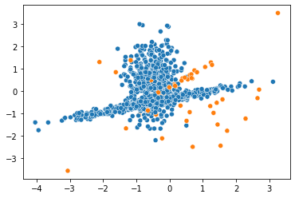

```python
dataset = make_classification(n_samples=num_samples, n_features=2, n_clusters_per_class=2,
                              n_classes=num_classes, weights=imbalance_ratio, flip_y=0, class_sep=0.5,
                              n_informative=2, n_redundant=0, n_repeated=0, random_state=seed)

X = dataset[0]
y = dataset[1]

sns.scatterplot(x=X[:,0], y=X[:,1], hue=y, legend=False)
```

Print the distribution of samples in the dataset classes:

```python
print("Class Distribution:")

for k in range(num_classes):
    print("Class", k, ":", len(y[y==k]), "samples")
```

```
Class Distribution:
Class 0 : 950 samples
Class 1 : 50 samples
```

We prepare the dataset for classification. We split it into a training and a test set in a ratio $4:1$; in other words, 80% of the original data will be used for training, and 20% will be used for testing. Stratifying by the target variable guarantees that the distributions of the dataset classes will be (about) the same in the training and test sets.

```python
from sklearn.model_selection import train_test_split

X_train, X_test, y_train, y_test = train_test_split(X, y, test_size=0.2, stratify=y, random_state=seed)
```

Print and plot the distribution of samples in the classes of the test set:

```
Class 0 : 190 samples
Class 1 : 10 samples
```

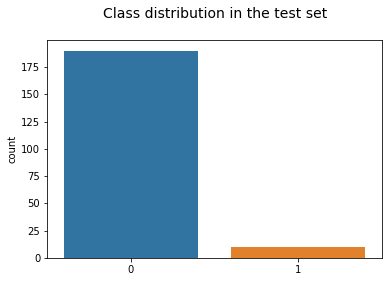

```python
for k in range(num_classes):
    print("Class", k, ":", len(y_test[y_test==k]), "samples")

sns.countplot(x=y_test)
plt.title('Class distribution in the test set\n', fontsize=14)
```

## Classification

We will use five simple machine learning models to perform classification:

```python
models = {
    "Logistic Regression": LogisticRegression(max_iter=300, random_state=seed),
    "Decision Tree": DecisionTreeClassifier(criterion='gini', max_depth=None, max_features=None, random_state=seed),
    "Random Forest": RandomForestClassifier(n_estimators=100, criterion='gini', max_depth=None, max_features='sqrt',
                                       n_jobs=8, random_state=seed),
    "SVM (RBF Kernel)": SVC(kernel='rbf', C=1, random_state=seed),
    "FCFF Neural Net": MLPClassifier(activation='relu', hidden_layer_sizes=(16, 4), solver='adam', random_state=seed),
}

Results_over = []
```

`plot_decision_regions_2D()`: The following function plots the dataset and the decision boundaries that are determined by each classifier.

```python
def plot_decision_regions_2D(X, y, classifier, resolution=0.02):
    # setup marker generator and color map
    markers = ('o', 'o', 'o', 'o', 's', 'v', '^')
    colors = ('#1f77b4', '#ff7f0e', 'red', 'blue', 'lightgreen', 'gray', 'cyan')
    cmap = ListedColormap(colors[:len(np.unique(y))])

    # plot the decision surface
    x1_min, x1_max = X[:, 0].min() - 0.2, X[:, 0].max() + 0.2
    x2_min, x2_max = X[:, 1].min() - 0.2, X[:, 1].max() + 0.2

    # meshgrid: Return coordinate matrices from coordinate vectors. More specifically, we make N-D coordinate arrays
    # for vectorized evaluations of N-D scalar/vector fields over N-D grids, given one-dimensional coordinate arrays.
    xx1, xx2 = np.meshgrid(np.arange(x1_min, x1_max, resolution), np.arange(x2_min, x2_max, resolution))

    # ravel: Return a contiguous flattened array.
    # T: the transpose matrix
    X_test_in = np.array([xx1.ravel(), xx2.ravel()]).T
    # print(X_test)

    Z = classifier.predict(X_test_in)
    Z = Z.reshape(xx1.shape)

    plt.contourf(xx1, xx2, Z, alpha=0.15, cmap=cmap)
    plt.xlim(xx1.min(), xx1.max())
    plt.ylim(xx2.min(), xx2.max())

    for idx, cl in enumerate(np.unique(y)):
        plt.scatter(x=X[y==cl,0], y=X[y==cl,1], alpha=0.8, c=colors[idx], marker=markers[idx], label=cl, edgecolor='white')
```

`TrainTestModel()`: A parametric function that trains and tests a classifier.

```python
def TrainTestModel(train_X, test_X, train_y, test_y, mdl, res, desc):

        t0 = time.time()
        print("Training", mdl + "...\t", end="", flush=True)

        clf = models[mdl]
        clf.fit(train_X, train_y)

        print("  (%5.3f sec). \t" % (time.time() - t0), end="", flush=True)

        y_predicted = clf.predict(test_X)

        acc = accuracy_score(test_y, y_predicted)
        bacc = balanced_accuracy_score(test_y, y_predicted)

        if num_classes == 2:
            fpr, tpr, thresholds = roc_curve(test_y, y_predicted)
            auc_m = auc(fpr, tpr)
        else:
            auc_m = bacc

        print("Accuracy=%5.4f" % acc, "\tBalanced Accuracy=%5.4f"% bacc, "\tAUC=%5.4f" % auc_m, flush=True)

        res.append([mdl, desc, acc, bacc, auc_m])

        X_stacked = np.vstack((train_X, test_X))
        Y_stacked = np.hstack((train_y, test_y))

        plot_decision_regions_2D(X_stacked, Y_stacked, clf)
        plt.xlabel("x0")
        plt.ylabel("x1")
        plt.title(mdl + " (Accuracy: " + (str)(round(acc, 3)) + ", AUC: " + (str)(round(auc_m, 3)) + ")")
        plt.legend(loc='upper left')
```

## Training and testing the classifiers on the original dataset

```
Training Logistic Regression...	  (0.008 sec). 	Accuracy=0.9500 	Balanced Accuracy=0.5000 	AUC=0.5000
Training Decision Tree...	  (0.000 sec). 	Accuracy=0.9600 	Balanced Accuracy=0.6947 	AUC=0.6947
Training Random Forest...	  (0.069 sec). 	Accuracy=0.9650 	Balanced Accuracy=0.6500 	AUC=0.6500
Training SVM (RBF Kernel)...	  (0.004 sec). 	Accuracy=0.9600 	Balanced Accuracy=0.6000 	AUC=0.6000
Training FCFF Neural Net...	  (0.128 sec). 	Accuracy=0.9550 	Balanced Accuracy=0.5500 	AUC=0.5500
```

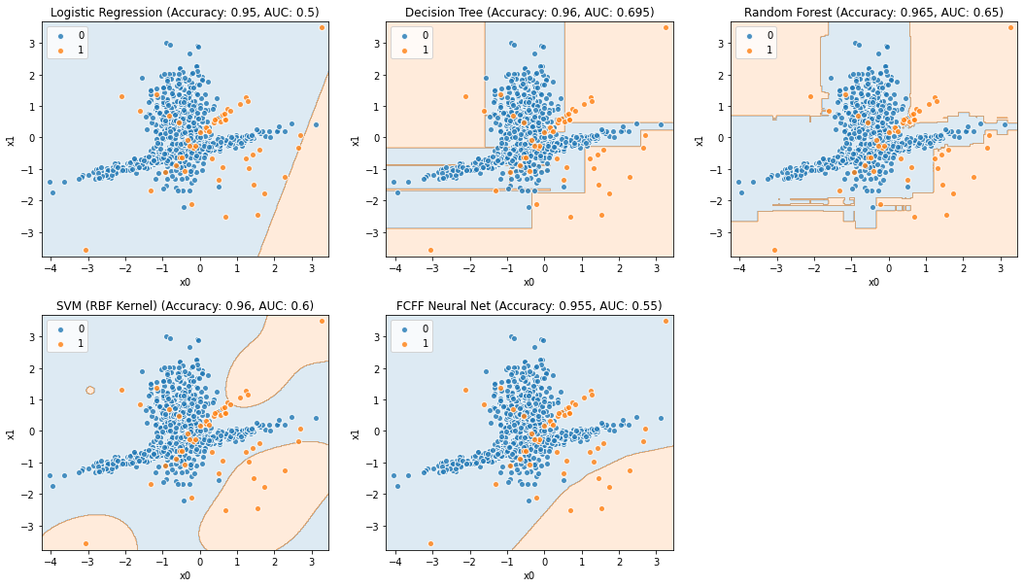

```python
fig = plt.figure(figsize=(18, 10))

itr = 0

for model in models:
    itr = itr + 1
    plt.subplot(2, 3, itr)
    TrainTestModel(X_train, X_test, y_train, y_test, model, Results_over, "Original data")

plt.subplots_adjust(hspace=0.25)

Results_under = Results_over.copy()
```

## Tackling class imbalance

The `sampling_strategy` parameter is defined by the ratio $\alpha={N_{min}}/{N_{maj}}$ where:

- ${N_{min}}$ is the number of samples in the minority class and
- ${N_{maj}}$ is the number of samples in the majority class after resampling.

```python
import imblearn
print(imblearn.__version__)

alpha = imbalance_ratio[1] / imbalance_ratio[0]
```

```
0.10.1
```

## Oversampling

```python
X_train, X_test, y_train, y_test = train_test_split(X, y, test_size=0.2, stratify=y, random_state=seed)
```

### Random oversampling (ROS)

The simplest approach involves duplicating examples in the minority class, although these examples don't add any new information to the model. Instead, new examples can be synthesized from the existing examples.

```
Training Logistic Regression...	  (0.004 sec). 	Accuracy=0.7750 	Balanced Accuracy=0.7868 	AUC=0.7868
Training Decision Tree...	  (0.004 sec). 	Accuracy=0.9600 	Balanced Accuracy=0.6947 	AUC=0.6947
Training Random Forest...	  (0.076 sec). 	Accuracy=0.9650 	Balanced Accuracy=0.6974 	AUC=0.6974
Training SVM (RBF Kernel)...	  (0.024 sec). 	Accuracy=0.9450 	Balanced Accuracy=0.7342 	AUC=0.7342
Training FCFF Neural Net...	  (0.252 sec). 	Accuracy=0.9350 	Balanced Accuracy=0.8237 	AUC=0.8237
```

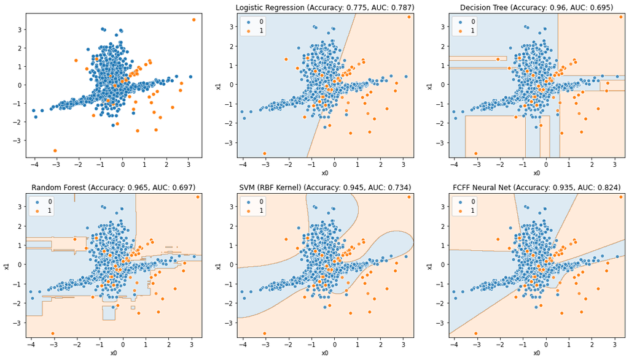

```python
from imblearn.over_sampling import RandomOverSampler

# sampling_strategy: we oversample the minority class to make it equal to the majority class
oversample = RandomOverSampler(sampling_strategy='auto')
X_over_train, y_over_train = oversample.fit_resample(X_train, y_train)

fig = plt.figure(figsize=(18, 10))
plt.subplot(2, 3, 1)
sns.scatterplot(x=X[:,0], y=X[:,1], hue=y, legend=False)

itr = 1
for model in models:
    itr = itr + 1
    plt.subplot(2, 3, itr)
    TrainTestModel(X_over_train, X_test, y_over_train, y_test, model, Results_over, "ROS")

plt.subplots_adjust(hspace=0.25)
```

### Synthetic Minority Oversampling Technique (SMOTE)

- N.V. Chawla, K.W. Bowyer, L. O Hall, W.P. Kegelmeyer, "SMOTE: Synthetic Minority Over-sampling Technique", *Journal of Artificial Intelligence Research*, 16:321–357, 2002.

This is a type of data augmentation for the minority class and is referred to as the Synthetic Minority Oversampling Technique, or SMOTE for short. The algorithm goes through the following steps:

- Choose a random sample $x_i$ from the minority class.
- Find its $k$ nearest neighbors (typically $k=5$).
- Pick a neighbor $x_i^n$ and generate a synthetic sample in a random point of the line that connects $x_i$ and $x_i^n$: $$x_{syn}=x_i+\lambda(x_i-x_i^n)$$

This procedure can be used to create as many synthetic examples for the minority class as are required. The main advantage of SMOTE it that the synthetic minority examples are relatively close in feature space to existing examples from the minority class. Therefore, the class distribution is not affected much.

However, the synthetic examples are created without considering the majority class, possibly resulting in ambiguous examples if there is a strong overlap for the classes.

```
Training Logistic Regression...	  (0.004 sec). 	Accuracy=0.7700 	Balanced Accuracy=0.7842 	AUC=0.7842
Training Decision Tree...	  (0.000 sec). 	Accuracy=0.8550 	Balanced Accuracy=0.6868 	AUC=0.6868
Training Random Forest...	  (0.076 sec). 	Accuracy=0.8550 	Balanced Accuracy=0.7342 	AUC=0.7342
Training SVM (RBF Kernel)...	  (0.024 sec). 	Accuracy=0.9400 	Balanced Accuracy=0.7789 	AUC=0.7789
Training FCFF Neural Net...	  (0.280 sec). 	Accuracy=0.9500 	Balanced Accuracy=0.7842 	AUC=0.7842
```

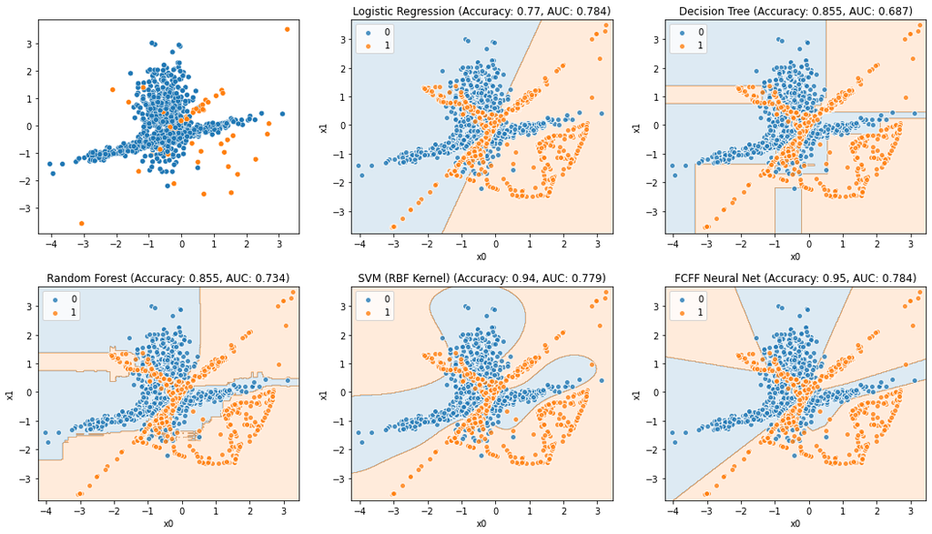

```python
from imblearn.over_sampling import SMOTE

# sampling_strategy: we oversample the minority class to make it equal to the majority class
oversample = SMOTE(sampling_strategy='auto')
X_over_train, y_over_train = oversample.fit_resample(X_train, y_train)

fig = plt.figure(figsize=(18, 10))
plt.subplot(2, 3, 1)
sns.scatterplot(x=X[:,0], y=X[:,1], hue=y, legend=False)

itr = 1
for model in models:
    itr = itr + 1
    plt.subplot(2, 3, itr)
    TrainTestModel(X_over_train, X_test, y_over_train, y_test, model, Results_over, "SMOTE")

plt.subplots_adjust(hspace=0.25)
```

### Borderline SMOTE

- H. Han, Wen-Yuan Wang, Bing-Huan Mao. "Borderline-SMOTE: A new over-sampling method in imbalanced data sets learning", *International Conference on Intelligent Computing*, 878–887. Springer, 2005.

SMOTE does not care about the "nature" of the minority samples to be used for synthetic data generation. Consequently, it may use outliers for synthetic data generation. This issue is effectively addressed by the Borderline-SMOTE variant.

More specifically, each sample $x_i$ from the minority class is categorized as:

- **Noise**, if all its nearest-neighbors belong to a different class,
- **In danger**, if at least half of its nearest neighbors belong to the same class,
- **Safe**, if all nearest neighbors are from the same class.

Borderline SMOTE uses only the samples "in danger" to generate new samples. It finds their $k$-nearest neighbors and generates samples over the line that connects them. The neighboring points must belong to the same class as the sample "in danger".

```
Training Logistic Regression...	  (0.008 sec). 	Accuracy=0.8200 	Balanced Accuracy=0.7632 	AUC=0.7632
Training Decision Tree...	  (0.004 sec). 	Accuracy=0.9250 	Balanced Accuracy=0.8184 	AUC=0.8184
Training Random Forest...	  (0.068 sec). 	Accuracy=0.9500 	Balanced Accuracy=0.7842 	AUC=0.7842
Training SVM (RBF Kernel)...	  (0.020 sec). 	Accuracy=0.9450 	Balanced Accuracy=0.7816 	AUC=0.7816
Training FCFF Neural Net...	  (0.250 sec). 	Accuracy=0.9600 	Balanced Accuracy=0.8368 	AUC=0.8368
```

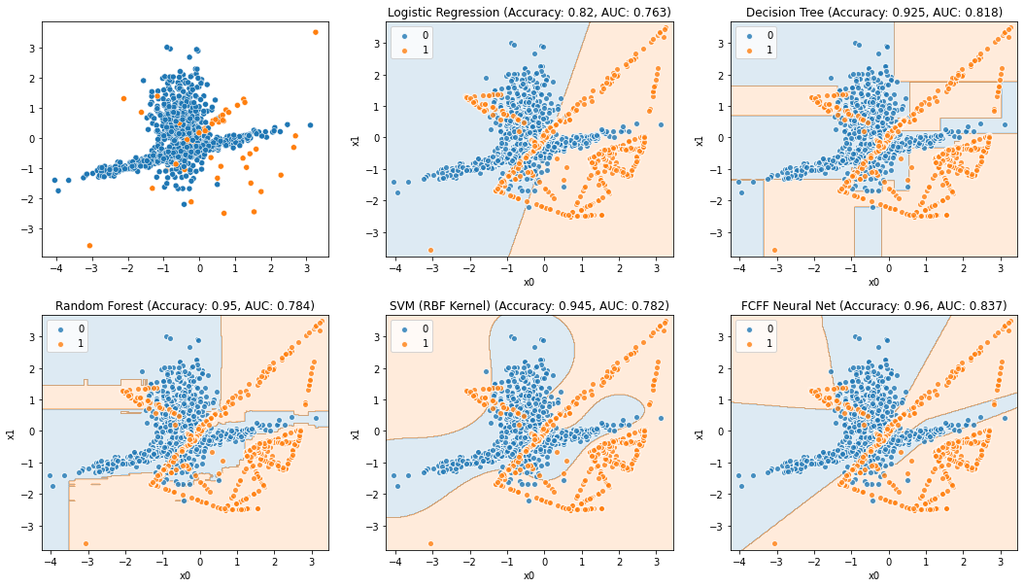

```python
from imblearn.over_sampling import BorderlineSMOTE

# sampling_strategy: we oversample the minority class to have 10 percent the number of examples of the majority class
oversample = BorderlineSMOTE(sampling_strategy='auto', random_state=seed)
X_over_train, y_over_train = oversample.fit_resample(X_train, y_train)

fig = plt.figure(figsize=(18, 10))
plt.subplot(2, 3, 1)
sns.scatterplot(x=X[:,0], y=X[:,1], hue=y, legend=False)

itr = 1
for model in models:
    itr = itr + 1
    plt.subplot(2, 3, itr)
    TrainTestModel(X_over_train, X_test, y_over_train, y_test, model, Results_over, "Borderline-SMOTE")

plt.subplots_adjust(hspace=0.25)
```

### SMOTE-SVM

- H.M. Nguyen, E.W. Cooper, K. Kamei. "Borderline Over-Sampling for Imbalanced Data Classification", *International Journal of Knowledge Engineering and Soft Data Paradigms*, 3(1): 4–21, 2011.

Unlike SMOTE and Borderline SMOTE that use $k$-nearest neighbors algorithm to generate synthetic samples, this technique uses an SVM classifier. The classifier is initially trained on the original training set. Then, synthetic data are randomly created along the lines joining each minority class support vector with a number of its nearest neighbors.

With SMOTE=SVM more data points are synthesized away from the region of class overlap. In other words, this technique focuses more on the region where the data is separated.

```
Training Logistic Regression...	  (0.000 sec). 	Accuracy=0.8450 	Balanced Accuracy=0.8237 	AUC=0.8237
Training Decision Tree...	  (0.000 sec). 	Accuracy=0.8950 	Balanced Accuracy=0.6132 	AUC=0.6132
Training Random Forest...	  (0.067 sec). 	Accuracy=0.9550 	Balanced Accuracy=0.7395 	AUC=0.7395
Training SVM (RBF Kernel)...	  (0.016 sec). 	Accuracy=0.9500 	Balanced Accuracy=0.7368 	AUC=0.7368
Training FCFF Neural Net...	  (0.248 sec). 	Accuracy=0.9600 	Balanced Accuracy=0.7895 	AUC=0.7895
```

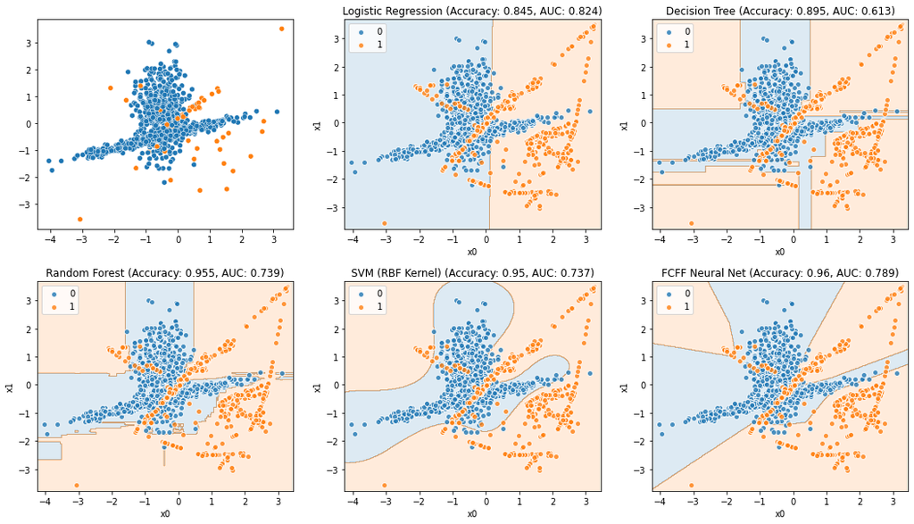

```python
from imblearn.over_sampling import SVMSMOTE

# sampling_strategy: we oversample the minority class to have 10 percent the number of examples of the majority class
oversample = SVMSMOTE(sampling_strategy='auto', random_state=seed)
X_over_train, y_over_train = oversample.fit_resample(X_train, y_train)

fig = plt.figure(figsize=(18, 10))
plt.subplot(2, 3, 1)
sns.scatterplot(x=X[:,0], y=X[:,1], hue=y, legend=False)

itr = 1
for model in models:
    itr = itr + 1
    plt.subplot(2, 3, itr)
    TrainTestModel(X_over_train, X_test, y_over_train, y_test, model, Results_over, "SMOTE-SVM")

plt.subplots_adjust(hspace=0.25)
```

### $k$-Means SMOTE

- G. Douzas, F. Bacao, F. Last, "Improving imbalanced learning through a heuristic oversampling method based on k-Means and SMOTE", *Information Sciences*, 465: 1-20, 2018.

$k$-Means SMOTE employs the $k$-Means clustering algorithm in conjunction with SMOTE to rebalance the dataset. It generates instances according to the cluster density. In this way, it confronts the intra-class imbalance. This method avoids the generation of noise in the safe area. It also pays attention to both inter-class and intra-class imbalance.

The algorithm is organized in three steps:

- **Clustering step**: It clusters the instances into $k$ groups by using $k$-Means.
- **Filtering step**: It selects the clusters to be oversampled and determines the number of instances to be generated in each cluster. The cluster selection is based on the proportion of minority and majority instances in each cluster. Any cluster with at least 50% of minority instances can be selected for oversampling. In the sequel, weights are assigned to the selected clusters to determine the instances to be created.
- **Oversampling step**: During this step, SMOTE is employed to oversample each selected cluster as follows:
  - We choose a random minority instance $x_i$ within a cluster.
  - We find one of its random minority neighbors $x_i^n$.
  - We determine a new instance $x_{syn}$ by interpolating $x_i$ and $x_i^n$

This process is repeated until the desired number of minority instances is eventually created.

```
Training Logistic Regression...	  (0.004 sec). 	Accuracy=0.8150 	Balanced Accuracy=0.7132 	AUC=0.7132
Training Decision Tree...	  (0.000 sec). 	Accuracy=0.9050 	Balanced Accuracy=0.6658 	AUC=0.6658
Training Random Forest...	  (0.068 sec). 	Accuracy=0.9200 	Balanced Accuracy=0.7211 	AUC=0.7211
Training SVM (RBF Kernel)...	  (0.020 sec). 	Accuracy=0.9400 	Balanced Accuracy=0.6842 	AUC=0.6842
Training FCFF Neural Net...	  (0.247 sec). 	Accuracy=0.9350 	Balanced Accuracy=0.7763 	AUC=0.7763
```

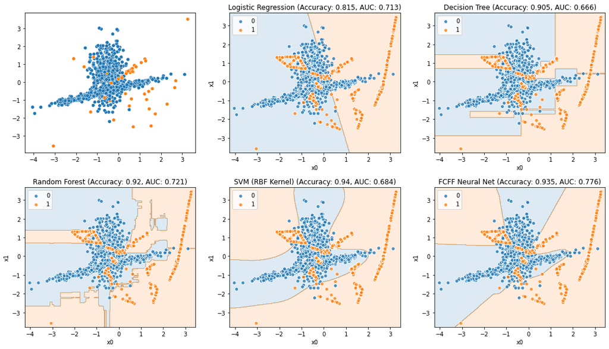

```python
from imblearn.over_sampling import KMeansSMOTE

# sampling_strategy: we oversample the minority class to have 10 percent the number of examples of the majority class
oversample = KMeansSMOTE(sampling_strategy='auto', cluster_balance_threshold=0.01, random_state=seed)
X_over_train, y_over_train = oversample.fit_resample(X_train, y_train)

fig = plt.figure(figsize=(18, 10))
plt.subplot(2, 3, 1)
sns.scatterplot(x=X[:,0], y=X[:,1], hue=y, legend=False)

itr = 1
for model in models:
    itr = itr + 1
    plt.subplot(2, 3, itr)
    TrainTestModel(X_over_train, X_test, y_over_train, y_test, model, Results_over, "kMeans-SMOTE")

plt.subplots_adjust(hspace=0.25)
```

### ADASYN

- H. He, Y. Bai, E.A. Garcia, S. Li. "ADASYN: Adaptive Synthetic Sampling Approach for Imbalanced Learning". In *2008 IEEE International Joint Conference on Neural Networks*, 1322–1328. IEEE, 2008.

ADASYN determines the number of synthetic examples that need to be generated for each minority example by the amount of its majority nearest neighbors. The more majority nearest neighbors, the more synthetic examples will be created.

The menthod is based on a density distribution $\Gamma_i$ as a criterion to decide the number of synthetic examples; while in SMOTE, each minority example has an equal chance of being selected for synthetic process.

```
Training Logistic Regression...	  (0.004 sec). 	Accuracy=0.7300 	Balanced Accuracy=0.8579 	AUC=0.8579
Training Decision Tree...	  (0.004 sec). 	Accuracy=0.8350 	Balanced Accuracy=0.7711 	AUC=0.7711
Training Random Forest...	  (0.080 sec). 	Accuracy=0.8450 	Balanced Accuracy=0.7289 	AUC=0.7289
Training SVM (RBF Kernel)...	  (0.028 sec). 	Accuracy=0.8850 	Balanced Accuracy=0.7026 	AUC=0.7026
Training FCFF Neural Net...	  (0.270 sec). 	Accuracy=0.9100 	Balanced Accuracy=0.8579 	AUC=0.8579
```

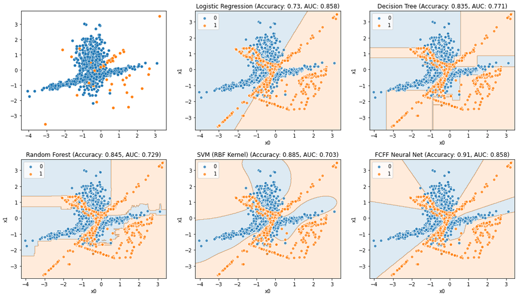

```python
from imblearn.over_sampling import ADASYN

# sampling_strategy: we oversample the minority class to have 10 percent the number of examples of the majority class
oversample = ADASYN(sampling_strategy='auto', random_state=seed)
X_over_train, y_over_train = oversample.fit_resample(X_train, y_train)

fig = plt.figure(figsize=(18, 10))
plt.subplot(2, 3, 1)
sns.scatterplot(x=X[:,0], y=X[:,1], hue=y, legend=False)

itr = 1
for model in models:
    itr = itr + 1
    plt.subplot(2, 3, itr)
    TrainTestModel(X_over_train, X_test, y_over_train, y_test, model, Results_over, "ADASYN")

plt.subplots_adjust(hspace=0.25)
```

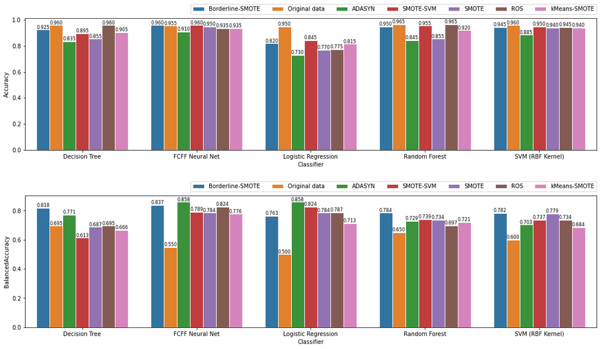

```python
df_results = pd.DataFrame(Results_over, columns=['Classifier', 'Method', 'Accuracy', 'BalancedAccuracy', 'AUC']). \
    sort_values(['Classifier'], ascending=[True])

fig = plt.figure(figsize=(18, 10))

plt.subplot(2, 1, 1)
ax = sns.barplot(data=df_results, x="Classifier", y="Accuracy", hue="Method", edgecolor='white')
plt.legend(bbox_to_anchor=(1, 1.07), loc='right', borderaxespad=0, ncol=7)
for i in ax.containers:
    ax.bar_label(i, fmt='%.3f', fontsize=8)


plt.subplot(2, 1, 2)
ax = sns.barplot(data=df_results, x="Classifier", y="BalancedAccuracy", hue="Method", edgecolor='white')
plt.legend(bbox_to_anchor=(1, 1.07), loc='right', borderaxespad=0, ncol=7)
for i in ax.containers:
    ax.bar_label(i, fmt='%.3f', fontsize=8)


plt.subplots_adjust(hspace=0.35)
```

## Undersampling

Α preprocessing technique that brings balance to a dataset by reducing the population of the majority class. We mainly encounter two approaches:

- **Prototype selection:** Selects the samples to be removed from the targeted classes;
- **Prototype generation:** Reduces the number of samples in the targeted classes; the remaining samples are generated -not selected- from the original set.

### Random undersampling

The simplest Prototype Selection undersampling technique. It randomly selects a subset of data for the targeted classes.

```
Training Logistic Regression...	  (0.000 sec). 	Accuracy=0.8050 	Balanced Accuracy=0.8026 	AUC=0.8026
Training Decision Tree...	  (0.000 sec). 	Accuracy=0.6950 	Balanced Accuracy=0.6974 	AUC=0.6974
Training Random Forest...	  (0.062 sec). 	Accuracy=0.8100 	Balanced Accuracy=0.8526 	AUC=0.8526
Training SVM (RBF Kernel)...	  (0.000 sec). 	Accuracy=0.8950 	Balanced Accuracy=0.7553 	AUC=0.7553
Training FCFF Neural Net...	  (0.031 sec). 	Accuracy=0.8250 	Balanced Accuracy=0.7658 	AUC=0.7658
```

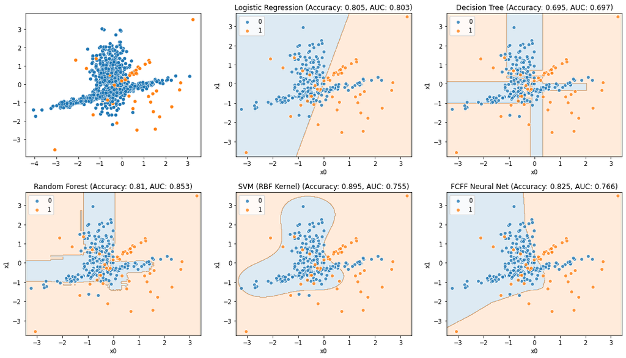

```python
from imblearn.under_sampling import RandomUnderSampler

# sampling_strategy: we oversample the minority class to have 10 percent the number of examples of the majority class
undersample = RandomUnderSampler(sampling_strategy='auto', replacement=True, random_state=seed)
X_under_train, y_under_train = undersample.fit_resample(X_train, y_train)

fig = plt.figure(figsize=(18, 10))
plt.subplot(2, 3, 1)
sns.scatterplot(x=X[:,0], y=X[:,1], hue=y, legend=False)

itr = 1
for model in models:
    itr = itr + 1
    plt.subplot(2, 3, itr)
    TrainTestModel(X_under_train, X_test, y_under_train, y_test, model, Results_under, "Random Undersampling")

plt.subplots_adjust(hspace=0.25)
```

### NearMiss (version 1)

NearMiss-1 selects the positive samples for which the average distance to the $k$ closest samples of the negative class is the smallest.

```
Training Logistic Regression...	  (0.016 sec). 	Accuracy=0.8200 	Balanced Accuracy=0.7632 	AUC=0.7632
Training Decision Tree...	  (0.000 sec). 	Accuracy=0.2050 	Balanced Accuracy=0.4868 	AUC=0.4868
Training Random Forest...	  (0.069 sec). 	Accuracy=0.1950 	Balanced Accuracy=0.4816 	AUC=0.4816
Training SVM (RBF Kernel)...	  (0.000 sec). 	Accuracy=0.4400 	Balanced Accuracy=0.4684 	AUC=0.4684
Training FCFF Neural Net...	  (0.031 sec). 	Accuracy=0.4550 	Balanced Accuracy=0.5711 	AUC=0.5711
```

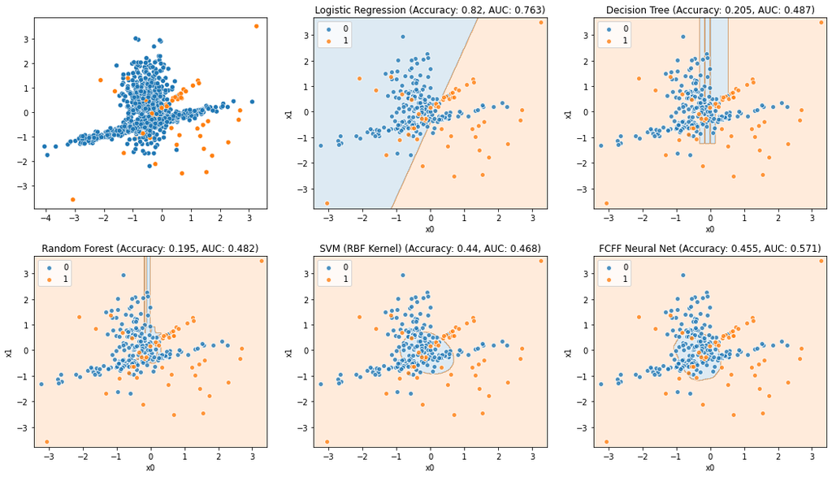

```python
from imblearn.under_sampling import NearMiss

undersample = NearMiss(version=1, sampling_strategy='auto', n_neighbors=5)
X_under_train, y_under_train = undersample.fit_resample(X_train, y_train)

fig = plt.figure(figsize=(18, 10))
plt.subplot(2, 3, 1)
sns.scatterplot(x=X[:,0], y=X[:,1], hue=y, legend=False)

itr = 1
for model in models:
    itr = itr + 1
    plt.subplot(2, 3, itr)
    TrainTestModel(X_under_train, X_test, y_under_train, y_test, model, Results_under, "NearMiss-1")

plt.subplots_adjust(hspace=0.25)
```

### NearMiss (version 2)

NearMiss-2 selects the positive samples for which the average distance to the $k$ farthest samples of the negative class is the smallest.

```
Training Logistic Regression...	  (0.000 sec). 	Accuracy=0.4850 	Balanced Accuracy=0.4447 	AUC=0.4447
Training Decision Tree...	  (0.000 sec). 	Accuracy=0.1400 	Balanced Accuracy=0.5474 	AUC=0.5474
Training Random Forest...	  (0.053 sec). 	Accuracy=0.1400 	Balanced Accuracy=0.4526 	AUC=0.4526
Training SVM (RBF Kernel)...	  (0.000 sec). 	Accuracy=0.2050 	Balanced Accuracy=0.4395 	AUC=0.4395
Training FCFF Neural Net...	  (0.031 sec). 	Accuracy=0.2350 	Balanced Accuracy=0.3605 	AUC=0.3605
```

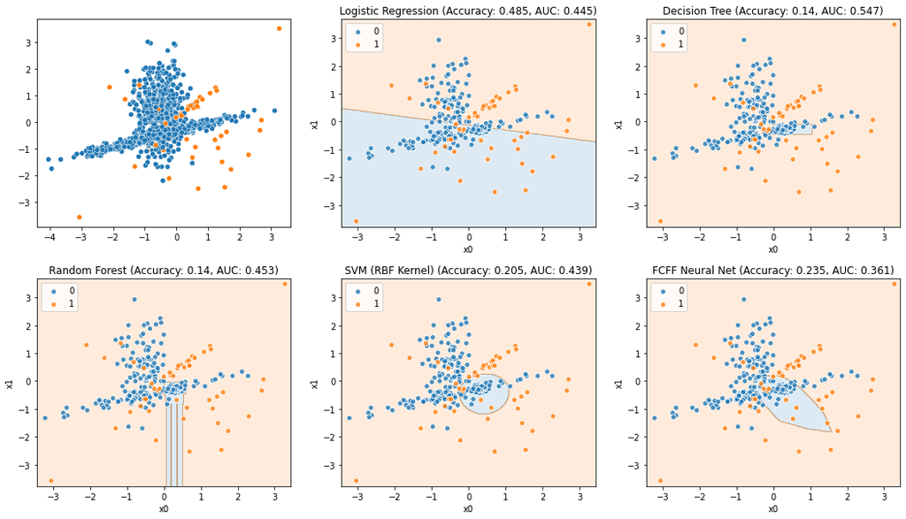

```python
undersample = NearMiss(version=2, sampling_strategy='auto', n_neighbors=5)
X_under_train, y_under_train = undersample.fit_resample(X_train, y_train)

fig = plt.figure(figsize=(18, 10))
plt.subplot(2, 3, 1)
sns.scatterplot(x=X[:,0], y=X[:,1], hue=y, legend=False)

itr = 1
for model in models:
    itr = itr + 1
    plt.subplot(2, 3, itr)
    TrainTestModel(X_under_train, X_test, y_under_train, y_test, model, Results_under, "NearMiss-2")

plt.subplots_adjust(hspace=0.25)
```

### NearMiss (version 3)

NearMiss-3 is a 2-step algorithm.

- Step 1: identify the $k$-nearest neighbors of the negative samples.
- Step 2: select the positive samples for which the average distance to the nearest-neighbors is the largest.

```
Training Logistic Regression...	  (0.016 sec). 	Accuracy=0.8100 	Balanced Accuracy=0.7579 	AUC=0.7579
Training Decision Tree...	  (0.000 sec). 	Accuracy=0.4650 	Balanced Accuracy=0.5763 	AUC=0.5763
Training Random Forest...	  (0.053 sec). 	Accuracy=0.3600 	Balanced Accuracy=0.6158 	AUC=0.6158
Training SVM (RBF Kernel)...	  (0.000 sec). 	Accuracy=0.5400 	Balanced Accuracy=0.7579 	AUC=0.7579
Training FCFF Neural Net...	  (0.031 sec). 	Accuracy=0.5750 	Balanced Accuracy=0.7763 	AUC=0.7763
```

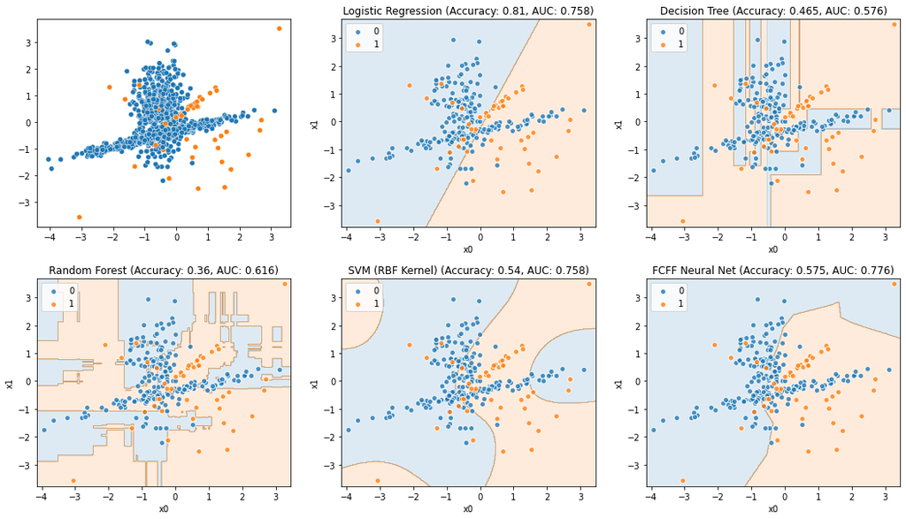

```python
undersample = NearMiss(version=3, sampling_strategy='auto', n_neighbors=5)
X_under_train, y_under_train = undersample.fit_resample(X_train, y_train)

fig = plt.figure(figsize=(18, 10))
plt.subplot(2, 3, 1)
sns.scatterplot(x=X[:,0], y=X[:,1], hue=y, legend=False)

itr = 1
for model in models:
    itr = itr + 1
    plt.subplot(2, 3, itr)
    TrainTestModel(X_under_train, X_test, y_under_train, y_test, model, Results_under, "NearMiss-3")

plt.subplots_adjust(hspace=0.25)
```

### Undersampling with clustering

Clustering is another effective way for undersampling the majority class on imbalanced datasets. The idea is that these algorithms construct homogeneous, complete clusters that group together similar data points. Therefore, an entire cluster of elements can be effectively replaced by a single representative element, e.g., cluster center, centroid, clustroid, etc. This key concept renders clustering an attractive approach to undersampling, because it enables the replacement of entire sample groups by a single, representative data point.

Lin et al. proposed two clustering strategies for undersampling, both based on the well-known 𝑘-Means algorithm. In the first strategy, the number of clusters to be constructed is determined by the population of the minority samples. The centroids of the generated clusters are subsequently utilized to replace the entire majority class, rendering the dataset perfectly balanced. The second strategy is very similar to the first one, except that we do not use the centroids as representative points, but their nearest neighbor. To demonstrate the effectiveness of their methods, the authors employed 44 small and 2 large datasets to train 5 different classifiers.

- Lin, W.C., Tsai, C.F., Hu, Y.H., Jhang, J.S.: “Clustering-based undersampling in class imbalanced data”, Information Sciences 409:17–26, 2017.

```
Training Logistic Regression...	  (0.000 sec). 	Accuracy=0.7550 	Balanced Accuracy=0.7763 	AUC=0.7763
Training Decision Tree...	  (0.008 sec). 	Accuracy=0.7700 	Balanced Accuracy=0.7842 	AUC=0.7842
Training Random Forest...	  (0.046 sec). 	Accuracy=0.8900 	Balanced Accuracy=0.8474 	AUC=0.8474
Training SVM (RBF Kernel)...	  (0.000 sec). 	Accuracy=0.8450 	Balanced Accuracy=0.8237 	AUC=0.8237
Training FCFF Neural Net...	  (0.020 sec). 	Accuracy=0.8300 	Balanced Accuracy=0.8158 	AUC=0.8158
```

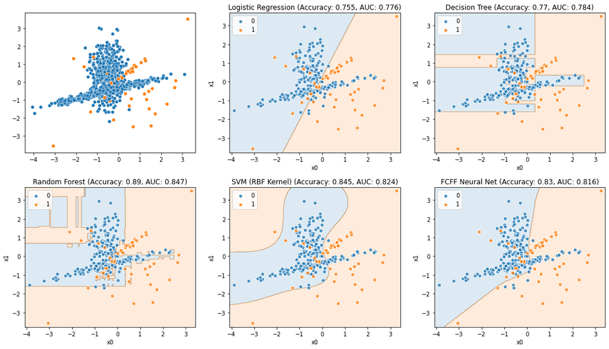

```python
from imblearn.under_sampling import ClusterCentroids
from sklearn.cluster import KMeans

clusterer = KMeans(n_clusters=8, init='random', random_state=seed)

undersample = ClusterCentroids(estimator=clusterer, sampling_strategy='auto', random_state=seed)
X_under_train, y_under_train = undersample.fit_resample(X_train, y_train)

fig = plt.figure(figsize=(18, 10))
plt.subplot(2, 3, 1)
sns.scatterplot(x=X[:,0], y=X[:,1], hue=y, legend=False)

itr = 1
for model in models:
    itr = itr + 1
    plt.subplot(2, 3, itr)
    TrainTestModel(X_under_train, X_test, y_under_train, y_test, model, Results_under, "Undersampling (clustering)")

plt.subplots_adjust(hspace=0.25)
```

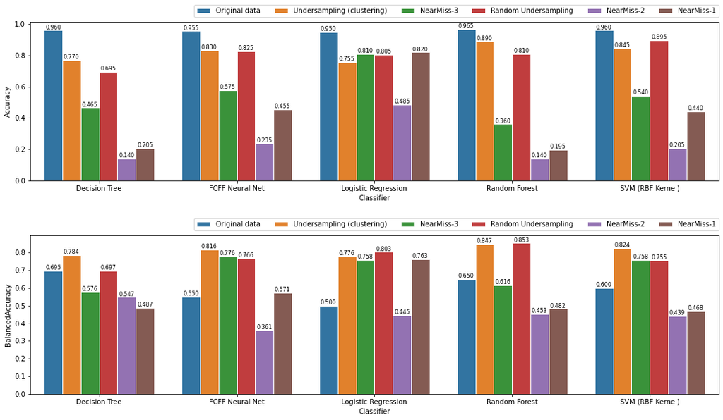

```python
df_results = pd.DataFrame(Results_under, columns=['Classifier', 'Method', 'Accuracy', 'BalancedAccuracy', 'AUC']). \
    sort_values(['Classifier'], ascending=[True])

fig = plt.figure(figsize=(18, 10))

plt.subplot(2, 1, 1)
ax = sns.barplot(data=df_results, x="Classifier", y="Accuracy", hue="Method", edgecolor='white')
plt.legend(bbox_to_anchor=(1, 1.07), loc='right', borderaxespad=0, ncol=6)
for i in ax.containers:
    ax.bar_label(i, fmt='%.3f', fontsize=8)


plt.subplot(2, 1, 2)
ax = sns.barplot(data=df_results, x="Classifier", y="BalancedAccuracy", hue="Method", edgecolor='white')
plt.legend(bbox_to_anchor=(1, 1.07), loc='right', borderaxespad=0, ncol=6)
for i in ax.containers:
    ax.bar_label(i, fmt='%.3f', fontsize=8)

plt.subplots_adjust(hspace=0.35)
```

## Hybrid sampling

Hybrid sampling combines both oversampling and undersampling to mitigate class imbalance.

Two strategies:

- **Udersampling/Oversampling**: First shrink the majority class with undersampling, then enlarge the minority classes by applying oversampling.
- **Oversampling/Udersampling**: First enlarge the minority classes by applying oversampling, then shrink the majority class with undersampling.

### Hybrid sampling strategy 1: undersampling followed by oversampling

This strategy first shrinks the majority class by using an undersampling technique, and then it enlarges the minority classes by applying oversampling.

The code block below defines two lists: `undersamplers` and `oversamplers`. They both contain tuples of three elements `(x, y, z)` where:

- `x` is a string that represents the undersampling/oversampling method,
- `y` is the imbalance ratio expressed as ${N_{min}}/{N_{maj}}$ where ${N_{min}}$ is the number of the minority samples and ${N_{maj}}$ is the number of the majority samples,
- `z` is the object of the corresponding undersampling/oversampling method.

```python
# Undersampling techniques: A list of tuples of three elements: [ (Method Description, Imbalance Ratio, Algorithm Object) ]
step = 0.05
undersamplers = []

lst = [ ("RUS-" + str(int(imb_ratio*100)), imb_ratio, RandomUnderSampler(sampling_strategy=imb_ratio, replacement=True, random_state=seed)) for imb_ratio in np.arange(alpha, 1.0, step) ]
undersamplers.extend(lst)

lst = [ ("NM1-" + str(int(imb_ratio*100)), imb_ratio, NearMiss(version=1, sampling_strategy=imb_ratio, n_neighbors=5)) for imb_ratio in np.arange(alpha, 1.0, step) ]
undersamplers.extend(lst)

lst = [ ("NM2-" + str(int(imb_ratio*100)), imb_ratio, NearMiss(version=2, sampling_strategy=imb_ratio, n_neighbors=5)) for imb_ratio in np.arange(alpha, 1.0, step) ]
undersamplers.extend(lst)

lst = [ ("NM3-" + str(int(imb_ratio*100)), imb_ratio, NearMiss(version=3, sampling_strategy=imb_ratio, n_neighbors=5)) for imb_ratio in np.arange(alpha, 1.0, step) ]
undersamplers.extend(lst)

lst = [ ("CLUS-" + str(int(imb_ratio*100)), imb_ratio, ClusterCentroids(estimator=clusterer, sampling_strategy=imb_ratio, random_state=seed)) for imb_ratio in np.arange(alpha, 1.0, step) ]
undersamplers.extend(lst)
# print(undersamplers)


# Oversampling techniques: A list of tuples of three elements: [ (Method Description, Imbalance Ratio, Algorithm Object) ]
oversamplers = []

lst = [ ("ROS-" + str(int(imb_ratio*100)), imb_ratio, RandomOverSampler(sampling_strategy=imb_ratio, random_state=seed)) for imb_ratio in np.arange(alpha, 1.0, step) ]
oversamplers.extend(lst)

lst = [ ("SMOTE-" + str(int(imb_ratio*100)), imb_ratio, SMOTE(sampling_strategy=imb_ratio, random_state=seed)) for imb_ratio in np.arange(alpha, 1.0, step) ]
oversamplers.extend(lst)

lst = [ ("BORSMOTE-" + str(int(imb_ratio*100)), imb_ratio, BorderlineSMOTE(sampling_strategy=imb_ratio, random_state=seed)) for imb_ratio in np.arange(alpha, 1.0, step) ]
oversamplers.extend(lst)

lst = [ ("SVMSMOTE-" + str(int(imb_ratio*100)), imb_ratio, SVMSMOTE(sampling_strategy=imb_ratio, random_state=seed)) for imb_ratio in np.arange(alpha, 1.0, step) ]
oversamplers.extend(lst)

lst = [ ("CLUSMOTE-" + str(int(imb_ratio*100)), imb_ratio, KMeansSMOTE(sampling_strategy=imb_ratio, cluster_balance_threshold=0.01, random_state=seed)) for imb_ratio in np.arange(alpha, 1.0, step) ]
oversamplers.extend(lst)

lst = [ ("ADASYN-" + str(int(imb_ratio*100)), imb_ratio, ADASYN(sampling_strategy=imb_ratio, random_state=seed)) for imb_ratio in np.arange(alpha, 1.0, step) ]
oversamplers.extend(lst)
# print(oversamplers)
```

```python
from tqdm.notebook import tqdm

Results_hybrid = []

for U in tqdm(undersamplers):
    # print("")

    for O in oversamplers:

        t0 = time.time()
        scenario = U[0] + " + " + O[0]
        # print("Testing scenario..." + scenario + "...\t", end="", flush=True)

        X_1_train, y_1_train = U[2].fit_resample(X_train, y_train)

        # print(str(len(y_1_train[y_1_train == 1])) + "/" + str(len(y_1_train[y_1_train == 0])))

        try:
            X_2_train, y_2_train = O[2].fit_resample(X_1_train, y_1_train)
        except:
            # print(" -> No oversampling", end="", flush=True)
            X_2_train = X_1_train
            y_2_train = y_1_train

        for mdl in models:
            # print("Training", mdl + "...\t", end="", flush=True)

            clf = models[mdl]
            clf.fit(X_2_train, y_2_train)

            # print("  (%5.3f sec). \t" % (time.time() - t0), end="", flush=True)

            y_predicted = clf.predict(X_test)

            acc = accuracy_score(y_test, y_predicted)
            bacc = balanced_accuracy_score(y_test, y_predicted)

            Results_hybrid.append([ scenario, mdl, acc, bacc ])

            # print("Accuracy=%5.4f" % acc, "\tBalanced Accuracy=%5.4f"% bacc, flush=True)

        # print("  (%5.3f sec). \t" % (time.time() - t0), flush=True)

df_results = pd.DataFrame(Results_hybrid, columns=['Scenario', 'Classifier', 'Accuracy', 'BalancedAccuracy'])
df_results.to_csv('hybrid_underover_results.csv')
```

### 20 best hybrid sampling scenarios (in terms of mean accuracy and mean balanced accuracy accross all classifiers)

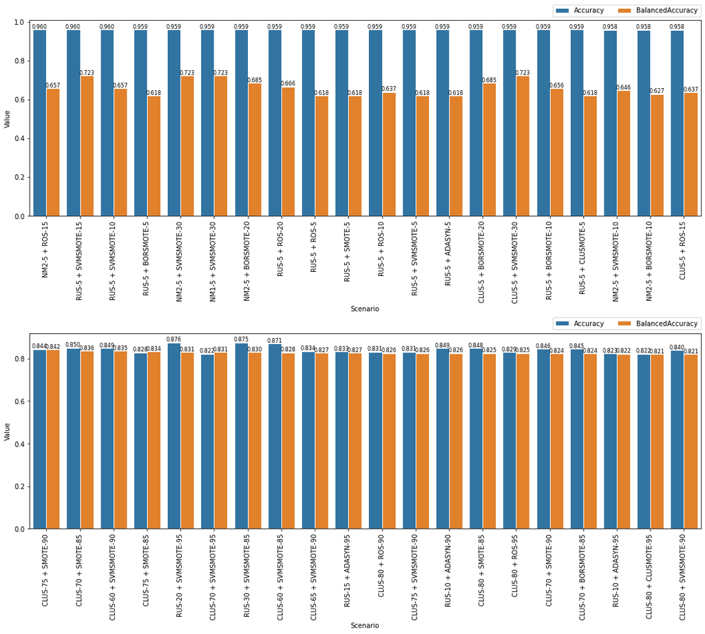

```python
df = pd.read_csv('hybrid_underover_results.csv')

fig = plt.figure(figsize=(18, 14))

# Plot the 20 best hybrid sampling scenario (in terms of accuracy)
# df_top20_acc = df.sort_values('Accuracy', ascending=False)
df_best = df.groupby('Scenario', as_index=False).mean().sort_values('Accuracy', ascending=False).head(20)
df_best = df_best.melt(id_vars=['Scenario'], value_vars=['Accuracy', 'BalancedAccuracy']).rename(columns=str.title)
df_best = df_best.sort_values(['Variable', 'Value'], ascending=[True, False])

plt.subplot(2, 1, 1)
ax = sns.barplot(data=df_best, x='Scenario', y='Value', hue='Variable', hue_order=['Accuracy', 'BalancedAccuracy'], edgecolor='white')
plt.legend(bbox_to_anchor=(1, 1.05), loc='right', borderaxespad=0, ncol=2)
ax.set_xticklabels(ax.get_xticklabels(), rotation=90)
for i in ax.containers:
    ax.bar_label(i, fmt='%.3f', fontsize=8)


# Plot the 20 best hybrid sampling scenario (in terms of balanced accuracy)
df_best = df.groupby('Scenario', as_index=False).mean().sort_values('BalancedAccuracy', ascending=False).head(20)
df_best = df_best.melt(id_vars=['Scenario'], value_vars=['Accuracy', 'BalancedAccuracy']).rename(columns=str.title)
df_best = df_best.sort_values(['Variable', 'Value'], ascending=[False, False])

plt.subplot(2, 1, 2)
ax = sns.barplot(data=df_best, x='Scenario', y='Value', hue='Variable', hue_order=['Accuracy', 'BalancedAccuracy'], edgecolor='white')
plt.legend(bbox_to_anchor=(1, 1.05), loc='right', borderaxespad=0, ncol=2)
ax.set_xticklabels(ax.get_xticklabels(), rotation=90)
for i in ax.containers:
    ax.bar_label(i, fmt='%.3f', fontsize=8)


plt.subplots_adjust(hspace=0.6)
```

### 20 best hybrid sampling scenarios (per classifier)

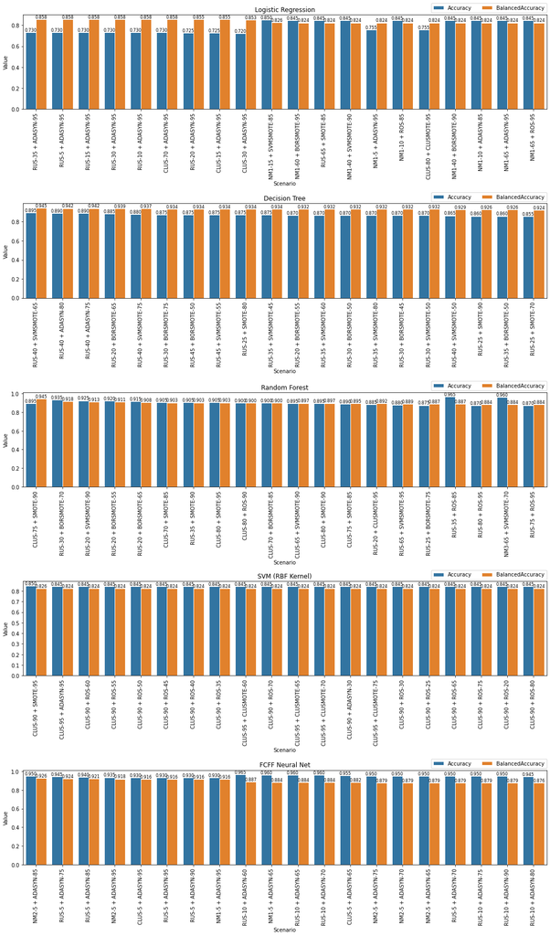

```python
df = pd.read_csv('hybrid_underover_results.csv')

num_models = len(models)
fig = plt.figure(figsize=(18, num_models * 6))
itr=0

for mdl in models:
    df_top20_acc = df[df.Classifier==mdl].sort_values(by='BalancedAccuracy', ascending=False).head(20)
    df_best= df_top20_acc.melt(id_vars=['Scenario'], value_vars=['Accuracy', 'BalancedAccuracy']).rename(columns=str.title)
    df_best = df_best.sort_values(['Variable', 'Value'], ascending=[False, False])

    itr=itr+1
    plt.subplot(num_models, 1, itr)
    plt.title(mdl)
    ax = sns.barplot(data=df_best, x='Scenario', y='Value', hue='Variable', hue_order=['Accuracy', 'BalancedAccuracy'], edgecolor='white')
    plt.legend(bbox_to_anchor=(1, 1.07), loc='right', borderaxespad=0, ncol=2)
    ax.set_xticklabels(ax.get_xticklabels(), rotation=90)
    for i in ax.containers:
        ax.bar_label(i, fmt='%.3f', fontsize=8)

plt.subplots_adjust(hspace=1.0)
```

### Hybrid sampling strategy 2: oversampling followed by undersampling

```python
Results_hybrid = []

for O in tqdm(oversamplers):

    for U in undersamplers:

        t0 = time.time()
        scenario = O[0] + " + " + U[0]
        # print("Testing scenario..." + scenario + "...\t", end="", flush=True)

        try:
            X_1_train, y_1_train = O[2].fit_resample(X_train, y_train)
        except:
            # print(" -> No oversampling", end="", flush=True)
            X_1_train = X_train
            y_1_train = y_train


        # print(str(len(y_1_train[y_1_train == 1])) + "/" + str(len(y_1_train[y_1_train == 0])))

        try:
            X_2_train, y_2_train = U[2].fit_resample(X_1_train, y_1_train)
        except:
            # print(" -> No undersampling", end="", flush=True)
            X_2_train = X_1_train
            y_2_train = y_1_train

        for mdl in models:
            # print("Training", mdl + "...\t", end="", flush=True)

            clf = models[mdl]
            clf.fit(X_2_train, y_2_train)

            # print("  (%5.3f sec). \t" % (time.time() - t0), end="", flush=True)

            y_predicted = clf.predict(X_test)

            acc = accuracy_score(y_test, y_predicted)
            bacc = balanced_accuracy_score(y_test, y_predicted)

            Results_hybrid.append([ scenario, mdl, acc, bacc ])

            # print("Accuracy=%5.4f" % acc, "\tBalanced Accuracy=%5.4f"% bacc, flush=True)

        # print("  (%5.3f sec). \t" % (time.time() - t0), flush=True)

df_results = pd.DataFrame(Results_hybrid, columns=['Scenario', 'Classifier', 'Accuracy', 'BalancedAccuracy'])
df_results.to_csv('hybrid_overunder_results.csv')
```

### 20 best hybrid sampling scenarios (in terms of mean accuracy and mean balanced accuracy accross all classifiers)

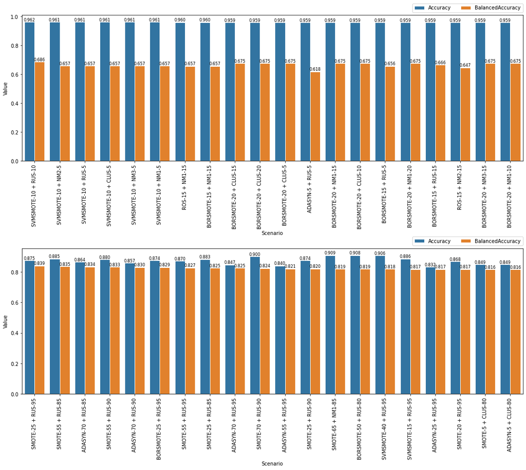

```python
df = pd.read_csv('hybrid_overunder_results.csv')

fig = plt.figure(figsize=(18, 14))

# Plot the 20 best hybrid sampling scenario (in terms of accuracy)
# df_top20_acc = df.sort_values('Accuracy', ascending=False)
df_best = df.groupby('Scenario', as_index=False).mean().sort_values('Accuracy', ascending=False).head(20)
df_best = df_best.melt(id_vars=['Scenario'], value_vars=['Accuracy', 'BalancedAccuracy']).rename(columns=str.title)
df_best = df_best.sort_values(['Variable', 'Value'], ascending=[True, False])

plt.subplot(2, 1, 1)
ax = sns.barplot(data=df_best, x='Scenario', y='Value', hue='Variable', hue_order=['Accuracy', 'BalancedAccuracy'], edgecolor='white')
plt.legend(bbox_to_anchor=(1, 1.05), loc='right', borderaxespad=0, ncol=2)
ax.set_xticklabels(ax.get_xticklabels(), rotation=90)
for i in ax.containers:
    ax.bar_label(i, fmt='%.3f', fontsize=8)


# Plot the 20 best hybrid sampling scenario (in terms of balanced accuracy)
df_best = df.groupby('Scenario', as_index=False).mean().sort_values('BalancedAccuracy', ascending=False).head(20)
df_best = df_best.melt(id_vars=['Scenario'], value_vars=['Accuracy', 'BalancedAccuracy']).rename(columns=str.title)
df_best = df_best.sort_values(['Variable', 'Value'], ascending=[False, False])

plt.subplot(2, 1, 2)
ax = sns.barplot(data=df_best, x='Scenario', y='Value', hue='Variable', hue_order=['Accuracy', 'BalancedAccuracy'], edgecolor='white')
plt.legend(bbox_to_anchor=(1, 1.05), loc='right', borderaxespad=0, ncol=2)
ax.set_xticklabels(ax.get_xticklabels(), rotation=90)
for i in ax.containers:
    ax.bar_label(i, fmt='%.3f', fontsize=8)


plt.subplots_adjust(hspace=0.6)
```

### 20 best hybrid sampling scenarios (per classifier)

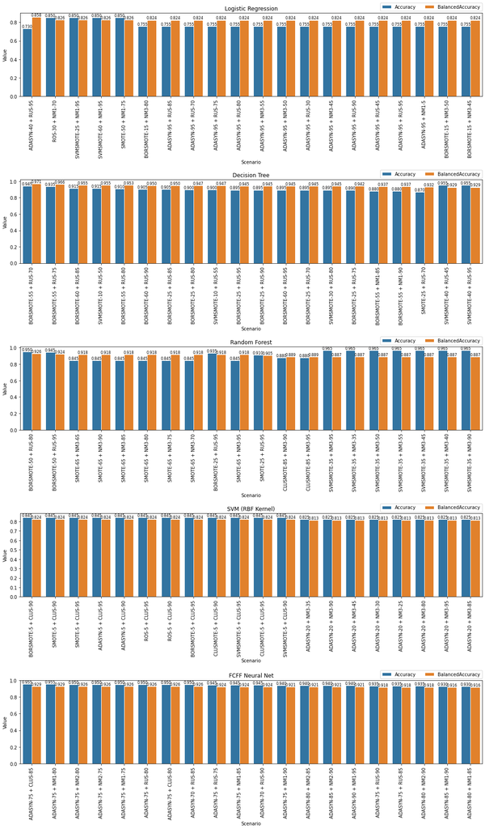

```python
df = pd.read_csv('hybrid_overunder_results.csv')

num_models = len(models)
fig = plt.figure(figsize=(18, num_models * 6))
itr=0

for mdl in models:
    df_top20_acc = df[df.Classifier==mdl].sort_values(by='BalancedAccuracy', ascending=False).head(20)
    df_best= df_top20_acc.melt(id_vars=['Scenario'], value_vars=['Accuracy', 'BalancedAccuracy']).rename(columns=str.title)
    df_best = df_best.sort_values(['Variable', 'Value'], ascending=[False, False])

    itr=itr+1
    plt.subplot(num_models, 1, itr)
    plt.title(mdl)
    ax = sns.barplot(data=df_best, x='Scenario', y='Value', hue='Variable', hue_order=['Accuracy', 'BalancedAccuracy'], edgecolor='white')
    plt.legend(bbox_to_anchor=(1, 1.07), loc='right', borderaxespad=0, ncol=2)
    ax.set_xticklabels(ax.get_xticklabels(), rotation=90)
    for i in ax.containers:
        ax.bar_label(i, fmt='%.3f', fontsize=8)

plt.subplots_adjust(hspace=1.0)
```